# Comparing IGBlast and CellRanger Gamma-Delta TCR

# Preparation

### Import all packages and set up working directory

```r
library(tidyverse)
library(dplyr)
knitr::opts_knit$set(progress = TRUE, verbose = TRUE, root.dir = '/home/local/')
```

### Load Data

```r
igblast <-  read_delim('Code/gamma-delta/results/all_contig_igblast_db-pass.tsv',"\t")
names(igblast)
igblast <- igblast %>% select(sequence_id, sequence, v_call, d_call, j_call, v_score, v_identity, d_score, d_identity, j_score, j_identity, stop_codon, vj_in_frame, locus, productive, cdr3) %>% rename_with(function(x) paste0(x,".igblast"))
cr3 <- read_csv('Code/gamma-delta/results/cellranger3.1_outs/all_contig_annotations.csv')
cr5 <- read_csv('Code/gamma-delta/results/cellranger5_outs/all_contig_annotations.csv')
vquest <- read_delim('Code/gamma-delta/results/vquest_airr.tsv',"\t")
vquest <- vquest %>% mutate(Query = str_sub(sequence_id, 0, -3)) %>% select(Query, v_call, d_call, j_call, v_score, v_identity, d_score, d_identity, j_score, j_identity, stop_codon, vj_in_frame, locus, productive)  %>% rename_with(function(x) paste0(x,".vquest"))
c_blast = read_delim('Code/gamma-delta/results/all_contig.TCR_constant.tab', col_names = F, delim='\t')
c_blast = constant %>% select(X1, X2,X3) %>% rename('contig_id'='X1','c_match'='X2','c_identity'='X3') %>% separate(c_match, into=c('c_allele', 'c_blast', 'c_species'),sep="\\|") %>% distinct()
```

### Parse the type names so that they are comparable

```r
joined <- full_join(igblast, vquest, by=c("sequence_id.igblast"="Query.vquest"))
# joined %>% filter(sequence_id=='CTCACACAGAGGTTAT-1_contig_1') %>% select(v_call.igblast, v_call.vquest)
joined <- joined %>%
  mutate(v_call.vquest = str_replace_all(v_call.vquest, 'Homsap', '')) %>%
  mutate(v_call.vquest = str_replace_all(v_call.vquest, 'ORF', '')) %>%
  mutate(v_call.vquest = str_replace_all(v_call.vquest, 'F', '')) %>%
  mutate(v_call.vquest = str_replace_all(v_call.vquest, ', or', ',')) %>%
  mutate(v_call.vquest = str_replace_all(v_call.vquest, 'or', ',')) %>%
  mutate(v_call.vquest = str_replace_all(v_call.vquest, fixed('()'), '')) %>%
  mutate(v_call.vquest = str_replace_all(v_call.vquest, ' ', ''))
joined <- joined %>%
  mutate(d_call.vquest = str_replace_all(d_call.vquest, 'Homsap', '')) %>%
  mutate(d_call.vquest = str_replace_all(d_call.vquest, 'ORF', '')) %>%
  mutate(d_call.vquest = str_replace_all(d_call.vquest, 'F', '')) %>%
  mutate(d_call.vquest = str_replace_all(d_call.vquest, 'or', '')) %>%
  mutate(d_call.vquest = str_replace_all(d_call.vquest, ' ', '')) %>%
  mutate(d_call.vquest = str_replace_all(d_call.vquest, fixed('_'), ''))
joined <- joined %>%
  mutate(j_call.vquest = str_replace_all(j_call.vquest, 'Homsap', '')) %>%
  mutate(j_call.vquest = str_replace_all(j_call.vquest, 'ORF', '')) %>%
  mutate(j_call.vquest = str_replace_all(j_call.vquest, 'F', '')) %>%
  mutate(j_call.vquest = str_replace_all(j_call.vquest, 'or', '')) %>%
  mutate(j_call.vquest = str_replace_all(j_call.vquest, ' ', ''))
```

# VQuest and IGMT

Heatmap shows that the two algorithms agree on whether a chain is productive, and if the VJ is in frame. VQuest generates a lot more NA values, but only a few disagreement exist otherwise.

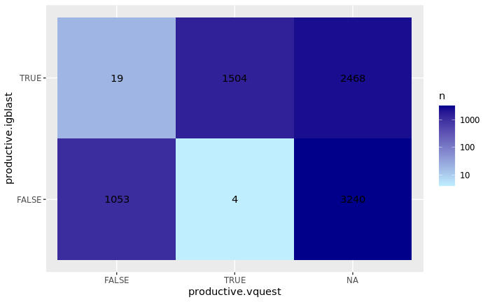

```r
joined %>%  replace_na(list(productive.igblast="NA")) %>% count(productive.vquest, productive.igblast) %>% ggplot(aes(x=productive.vquest, y=productive.igblast, fill=n)) + geom_tile() + scale_fill_gradient(low="lightblue1",high="darkblue",trans="log10") + geom_text(aes(label=n))
```

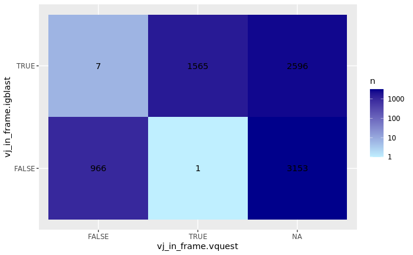

```r
joined %>%  replace_na(list(vj_in_frame.igblast="NA")) %>% count(vj_in_frame.vquest, vj_in_frame.igblast) %>% ggplot(aes(x=vj_in_frame.vquest, y=vj_in_frame.igblast, fill=n)) + geom_tile() + scale_fill_gradient(low="lightblue1",high="darkblue",trans="log10") + geom_text(aes(label=n))
```

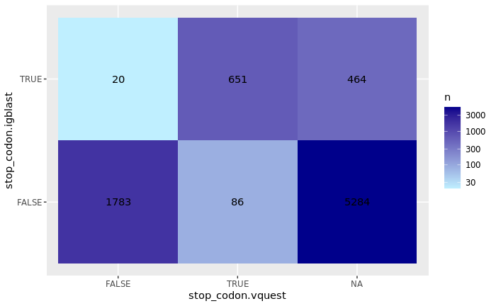

```r
joined %>%  replace_na(list(stop_codon.igblast="NA")) %>% count(stop_codon.vquest, stop_codon.igblast) %>% ggplot(aes(x=stop_codon.vquest, y=stop_codon.igblast, fill=n)) + geom_tile() + scale_fill_gradient(low="lightblue1",high="darkblue",trans="log10") + geom_text(aes(label=n))
```

```r
print(c(sum(is.na(joined['v_identity.igblast'])),sum(is.na(joined['d_identity.igblast'])),sum(is.na(joined['j_identity.igblast']))))
```

```
[1] 0 0 0
```

```r
print(c(sum(is.na(joined['v_identity.vquest'])),sum(is.na(joined['d_identity.vquest'])),sum(is.na(joined['j_identity.vquest']))))
```

```
[1] 0 0 0
```

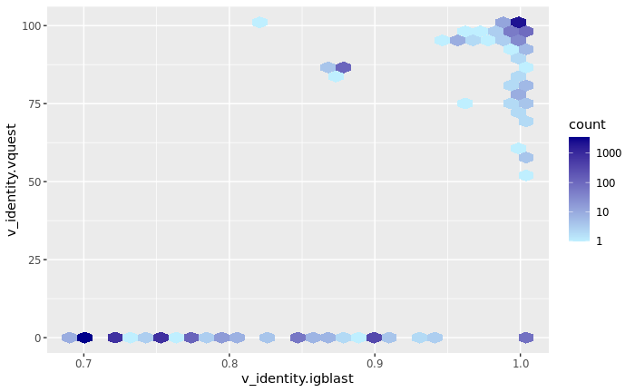

```r
joined <- joined %>% replace_na(list(v_identity.igblast=0, v_identity.vquest=0, d_identity.igblast=0, d_identity.vquest=0, j_identity.igblast=0, j_identity.vquest=0))

joined %>% ggplot(aes(x=v_identity.igblast, y=v_identity.vquest)) + geom_hex() +
  scale_fill_gradient(low="lightblue1",high="darkblue",trans="log10")
```

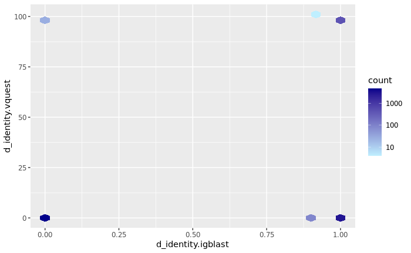

```r
joined %>% ggplot(aes(x=d_identity.igblast, y=d_identity.vquest)) + geom_hex() +
  scale_fill_gradient(low="lightblue1",high="darkblue",trans="log10")
```

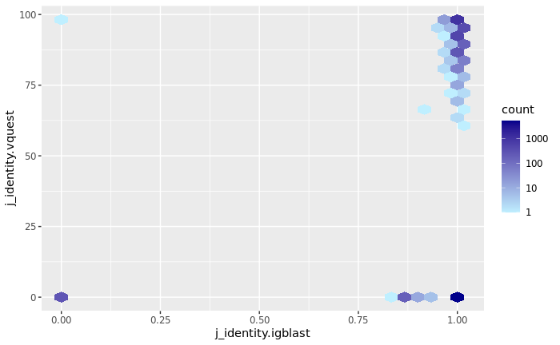

```r
joined %>% ggplot(aes(x=j_identity.igblast, y=j_identity.vquest)) + geom_hex() +
  scale_fill_gradient(low="lightblue1",high="darkblue",trans="log10")
```

### Variable gene identification between igblast and vquest

Table shows the percentage of disagreement if both algorithm gives a prediction

```r
joined <- joined %>% mutate(  V_agreement = str_detect(c(fixed(v_call.igblast)), fixed(v_call.vquest))|str_detect(c(fixed(v_call.vquest)), fixed(v_call.igblast)),
  D_agreement = str_detect(c(fixed(d_call.igblast)), fixed(d_call.vquest))|str_detect(c(fixed(d_call.vquest)), fixed(d_call.igblast)),
  J_agreement = str_detect(c(fixed(j_call.igblast)), fixed(j_call.vquest))|str_detect(c(fixed(j_call.vquest)), fixed(j_call.igblast)))

# use the following line to check that the different types are really different
joined %>% filter(!V_agreement) %>% count(v_call.igblast, v_call.vquest) %>% mutate(freq=n/sum(!is.na(joined['V_agreement'])))
```

| v_call.igblast | v_call.vquest | n | freq |
| --- | --- | --- | --- |
| TRAV35*01 | TRAV35*02 | 1 | 0.0003875969 |
| TRGV2*01 | TRGV2*02 | 16 | 0.0062015504 |

```r
joined %>% filter(!D_agreement) %>% count(d_call.igblast, d_call.vquest) %>% mutate(freq=n/sum(!is.na(joined['D_agreement'])))
```

| d_call.igblast | d_call.vquest | n | freq |
| --- | --- | --- | --- |
| TRDD3*01 | TRDD1*01 | 11 | 0.02528736 |
| TRDD3*01 | TRDD2*01 | 106 | 0.24367816 |

```r
joined %>% filter(!J_agreement) %>% count(j_call.igblast, j_call.vquest) %>% mutate(freq=n/sum(!is.na(joined['J_agreement'])))
```

| j_call.igblast | j_call.vquest | n | freq |
| --- | --- | --- | --- |
| TRAJ23*01,TRAJ23*02,TRAJ42*01 | TRAJ7*01 | 1 | 0.0003929273 |
| TRGJ1*02,TRGJ2*01 | TRGJ1*01 | 1 | 0.0003929273 |

Bar plot shows the frequency of: agree, disagree, or if either algorithm does not finding a match

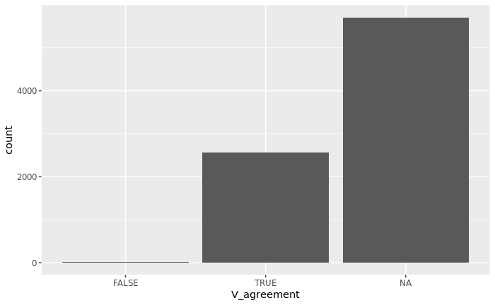

```r
joined %>% ggplot(aes(x=V_agreement))  + geom_bar()
```

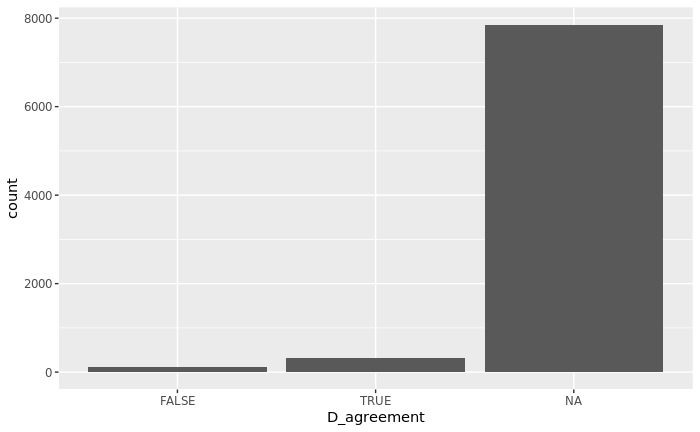

```r
joined %>% ggplot(aes(x=D_agreement))  + geom_bar()
```

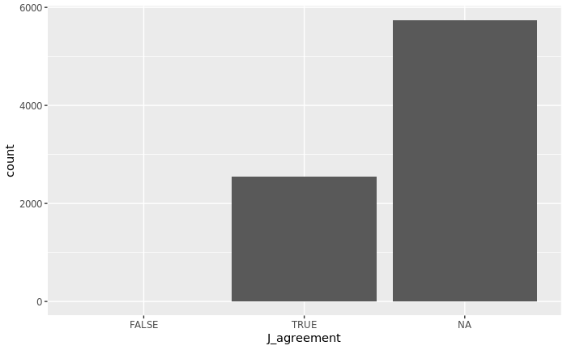

```r
joined %>% ggplot(aes(x=J_agreement))  + geom_bar()
```

# Combine CellRanger5 output and IGBLAST output

The TCR type between CellRanger5 and IGBLAST disagree with each other

```r
cr_igblast <- full_join(cr5, igblast, by=c("contig_id"="sequence_id.igblast"))
cr_igblast %>% count(locus.igblast, c_gene, productive.igblast, productive) %>% arrange(desc(n))
```

| locus.igblast | c_gene | productive.igblast | productive | n |
| --- | --- | --- | --- | --- |
| TRA | TRDC | TRUE | FALSE | 2379 |
| TRA | TRGC1 | FALSE | FALSE | 1576 |
| TRA | TRDC | FALSE | FALSE | 1318 |
| TRG | TRGC2 | FALSE | FALSE | 598 |
| TRG | TRGC2 | TRUE | FALSE | 598 |
| TRG | TRGC1 | TRUE | FALSE | 463 |
| TRD | TRDC | TRUE | FALSE | 425 |
| TRG | TRGC1 | FALSE | FALSE | 395 |
| TRB | TRDC | FALSE | FALSE | 205 |
| TRA | TRGC1 | TRUE | FALSE | 78 |

[output cut: 13 more lines]

The reason why igblast has very different prediction is because TRA and B are judged based on variable section and the reference for Gamma and Delta is not very good. Therefore we ran blastn on the constant region of TCR, and those are identified with high confidence. Except for the difference between TRGC2 and TRGC1, c_blast and cellranger agree with each other.

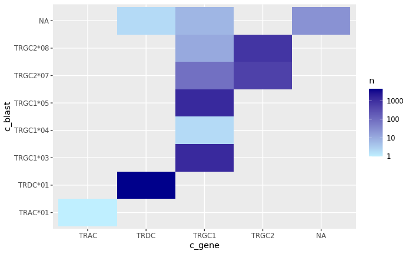

```r
cr_igblast_blast <- full_join(c_blast, cr_igblast, by=c("contig_id"="contig_id"))
cr_igblast_blast %>%  count(c_gene, c_blast) %>% ggplot(aes(x=c_gene, y=c_blast, fill=n)) + geom_tile()+
  scale_fill_gradient(low="lightblue1",high="darkblue",trans="log10")
```

### Variable gene identification between igblast and cellranger

Table shows the percentage of disagreement if both algorithm gives a prediction

```r
cr_igblast_blast <- cr_igblast_blast %>% mutate(V_agreement = str_detect(c(fixed(v_call.igblast)), fixed(v_gene))|str_detect(c(fixed(v_gene)), fixed(v_call.igblast)),
  D_agreement = str_detect(c(fixed(d_call.igblast)), fixed(d_gene))|str_detect(c(fixed(d_gene)), fixed(d_call.igblast)),
  J_agreement = str_detect(c(fixed(j_call.igblast)), fixed(j_gene))|str_detect(c(fixed(j_gene)), fixed(j_call.igblast)))
```

```
Coercing `pattern` to a plain character vector.Coercing `pattern` to a plain character vector.
```

```r
# use the following line to check that the different types are really different
cr_igblast_blast %>% filter(!V_agreement) %>% count(v_call.igblast, v_gene) %>% mutate(freq=n/sum(!is.na(cr_igblast_blast['V_agreement'])))
```

| v_call.igblast | v_gene | n | freq |
| --- | --- | --- | --- |
| TRAV17*01 | TRGV1 | 1 | 0.0003877472 |
| TRAV17*01 | TRGV8 | 1 | 0.0003877472 |
| TRGV2*01 | TRGV8 | 1 | 0.0003877472 |
| TRGV2*02 | TRGV8 | 1 | 0.0003877472 |
| TRGV3*01 | TRGV8 | 105 | 0.0407134548 |
| TRGV5*01 | TRGV3 | 1 | 0.0003877472 |
| TRGV5*01 | TRGV8 | 1 | 0.0003877472 |
| TRGV8*01 | TRGV2 | 1 | 0.0003877472 |
| TRGV8*01 | TRGV5 | 1 | 0.0003877472 |

```r
cr_igblast_blast %>% filter(!D_agreement) %>% count(d_call.igblast, d_gene) %>% mutate(freq=n/sum(!is.na(cr_igblast_blast['D_agreement'])))
```

| d_call.igblast | d_gene | n | freq |
| --- | --- | --- | --- |

```r
cr_igblast_blast %>% filter(!J_agreement) %>% count(j_call.igblast, j_gene) %>% mutate(freq=n/sum(!is.na(cr_igblast_blast['J_agreement'])))
```

| j_call.igblast | j_gene | n | freq |
| --- | --- | --- | --- |
| TRAJ1*01,TRAJ49*01 | TRDJ2 | 1 | 0.0001247349 |
| TRAJ10*01,TRAJ47*01 | TRDJ1 | 1 | 0.0001247349 |
| TRAJ13*01,TRAJ13*02 | TRGJ1 | 61 | 0.0076088312 |
| TRAJ13*01,TRAJ13*02 | TRGJP | 8 | 0.0009978795 |
| TRAJ13*01,TRAJ13*02 | TRGJP1 | 1499 | 0.1869776724 |
| TRAJ13*01,TRAJ13*02 | TRGJP2 | 5 | 0.0006236747 |
| TRAJ13*01,TRAJ13*02,TRAJ46*01 | TRDJ1 | 1 | 0.0001247349 |
| TRAJ15*01,TRAJ15*02,TRAJ3*01 | TRDJ1 | 786 | 0.0980416615 |
| TRAJ16*01,TRAJ16*02 | TRDJ2 | 25 | 0.0031183735 |
| TRAJ18*01 | TRGJP1 | 1 | 0.0001247349 |

[output cut: 64 more lines]

### Verify that A TCR must be in frame and do not have a stop codon to be productive

```r
cr_igblast%>%count(productive.igblast, stop_codon.igblast, vj_in_frame.igblast)
```

| productive.igblast | stop_codon.igblast | vj_in_frame.igblast | n |
| --- | --- | --- | --- |
| FALSE | FALSE | FALSE | 3162 |
| FALSE | TRUE | FALSE | 958 |
| FALSE | TRUE | TRUE | 177 |
| TRUE | FALSE | TRUE | 3991 |

### Check that there is a partial match between the cdr3 sequence predicted by either igblast or cellranger

There are 3666 cdr3 sequences that was only predicted by igblast and not cellranger, but out of the ones that they both predicted, most of them agree with each other

| cdr3_match | is.na(cdr3.igblast) | is.na(cdr3_nt) | n |
| --- | --- | --- | --- |
| FALSE | FALSE | FALSE | 54 |
| TRUE | FALSE | FALSE | 1619 |
| NA | FALSE | TRUE | 3666 |
| NA | TRUE | TRUE | 2950 |

### Check that the sequence length (in cellranger) is the same as the length of sequence (in igblast)

```r
sum(cr_igblast_blast%>%  mutate(len = str_length(sequence.igblast)) %>% select(len) == cr_igblast_blast['length']) ==dim(cr_igblast_blast)[1]
```

```
[1] TRUE
```

# Clean up cr_igblast and keep the relevant columns, then save the results

```r
names(cr_igblast_blast)
```

```
 [1] "contig_id"           "c_allele"            "c_blast"             "c_species"           "c_identity"          "barcode"             "is_cell"             "high_confidence"     "length"              "chain"
[11] "v_gene"              "d_gene"              "j_gene"              "c_gene"              "full_length"         "productive"          "cdr3"                "cdr3_nt"             "reads"               "umis"
[21] "raw_clonotype_id"    "raw_consensus_id"    "sequence.igblast"    "v_call.igblast"      "d_call.igblast"      "j_call.igblast"      "v_score.igblast"     "v_identity.igblast"  "d_score.igblast"     "d_identity.igblast"
[31] "j_score.igblast"     "j_identity.igblast"  "stop_codon.igblast"  "vj_in_frame.igblast" "locus.igblast"       "productive.igblast"  "cdr3.igblast"
```

```r
ann <- cr_igblast_blast %>% select(contig_id, barcode, is_cell, high_confidence, length,v_gene,v_call.igblast,v_identity.igblast, d_call.igblast, d_identity.igblast, j_gene,j_call.igblast,j_identity.igblast, c_gene, reads, umis, sequence.igblast, stop_codon.igblast, vj_in_frame.igblast, productive.igblast, cdr3.igblast, cdr3_nt )
write.csv(ann, file="Code/gamma-delta/results/all_contig_annotations.chenling.csv",
          row.names=FALSE)
```

# Clonal analysis results from IGBlast

```r
clonal <- read_delim('Code/gamma-delta/results/all_contig_igblast.clones.tsv', '\t', col_names = FALSE)
clonal_analysis <- lapply(c(1:100), function(i){
  clone <- str_split(clonal[i, 7], ',')[[1]]
  clone_summary <- ann %>% filter(contig_id %in% clone) %>% count(stop_codon.igblast,vj_in_frame.igblast, productive.igblast, v_gene,v_call.igblast,v_identity.igblast, d_call.igblast, d_identity.igblast, j_gene,j_call.igblast,j_identity.igblast) %>% mutate(rank=i)
  return(clone_summary)
})
clonal_analysis = bind_rows(clonal_analysis)
clonal_analysis %>% select(rank, stop_codon.igblast,vj_in_frame.igblast, productive.igblast, v_gene,v_call.igblast,v_identity.igblast, d_call.igblast, d_identity.igblast, j_gene,j_call.igblast,j_identity.igblast)
```

| rank | stop_codon.igblast | vj_in_frame.igblast | productive.igblast | v_gene | v_call.igblast | v_identity.igblast | d_call.igblast | d_identity.igblast | j_gene | j_call.igblast | j_identity.igblast |
| --- | --- | --- | --- | --- | --- | --- | --- | --- | --- | --- | --- |
| 1 | FALSE | TRUE | TRUE | NA | TRAV36/DV7*01 | 0.70588 | TRDD2*01 | 1 | TRDJ1 | TRDJ2*01 | 1.00000 |
| 2 | FALSE | TRUE | TRUE | NA | TRAV19*01 | 0.72500 | TRDD3*01 | 1 | TRGJ1 | TRDJ4*01 | 0.87500 |
| 2 | FALSE | TRUE | TRUE | NA | TRAV19*01 | 0.90000 | TRDD3*01 | 1 | TRGJ1 | TRDJ4*01 | 0.87500 |
| 2 | FALSE | TRUE | TRUE | NA | TRAV19*01 | 0.90000 | TRDD3*01 | 1 | TRGJP1 | TRDJ4*01 | 0.87500 |
| 3 | TRUE | FALSE | FALSE | NA | TRDV3*01,TRDV3*02 | 0.85000 | TRDD1*01 | 1 | TRGJP2 | TRDJ3*01 | 1.00000 |
| 3 | TRUE | FALSE | FALSE | NA | TRDV3*01,TRDV3*02 | 0.90000 | TRDD1*01 | 1 | TRGJP2 | TRDJ3*01 | 1.00000 |
| 4 | TRUE | FALSE | FALSE | NA | TRBV30*01,TRBV30*02,TRBV30*04 | 0.89474 | TRBD1*01 | 1 | TRDJ3 | TRBJ1-1*01 | 1.00000 |
| 5 | TRUE | FALSE | FALSE | NA | TRDV3*01,TRDV3*02 | 0.85000 | TRDD1*01,TRDD3*01 | 1 | TRGJP1 | TRDJ3*01 | 1.00000 |
| 5 | TRUE | FALSE | FALSE | NA | TRDV3*01,TRDV3*02 | 0.90000 | TRDD1*01,TRDD3*01 | 1 | TRGJP1 | TRDJ3*01 | 1.00000 |
| 5 | TRUE | FALSE | FALSE | NA | TRDV3*01,TRDV3*02 | 0.90000 | TRDD1*01,TRDD3*01 | 1 | TRGJP2 | TRDJ3*01 | 1.00000 |

[output cut: 106 more lines]

```r
write.csv(ann, file="Code/gamma-delta/results/clonal_analysis.igblast.csv",
          row.names=FALSE)
```